## Reproducible Research: Peer Assessment 1

### Loading and preprocessing the data

Below, the data are read using read.csv, then incomplete cases are eliminated and I split the data frame using split by $date.

```r
par(mfrow=c(1,1))
options(scipen=4)
activity_filename <- "activity.csv"
act <- read.csv(activity_filename, stringsAsFactors=FALSE)
complete_act <- act[complete.cases(act),]
bydate_act <- split(complete_act, complete_act$date, drop=TRUE)
coltest <- bydate_act[[1]][1:3,1:3]
```

### What is mean total number of steps taken per day?

This code calculates the mean # of steps taken per day by taking the split data sets and looping over them to sum the steps per day and then append to a list, then takes the mean & median of the list.

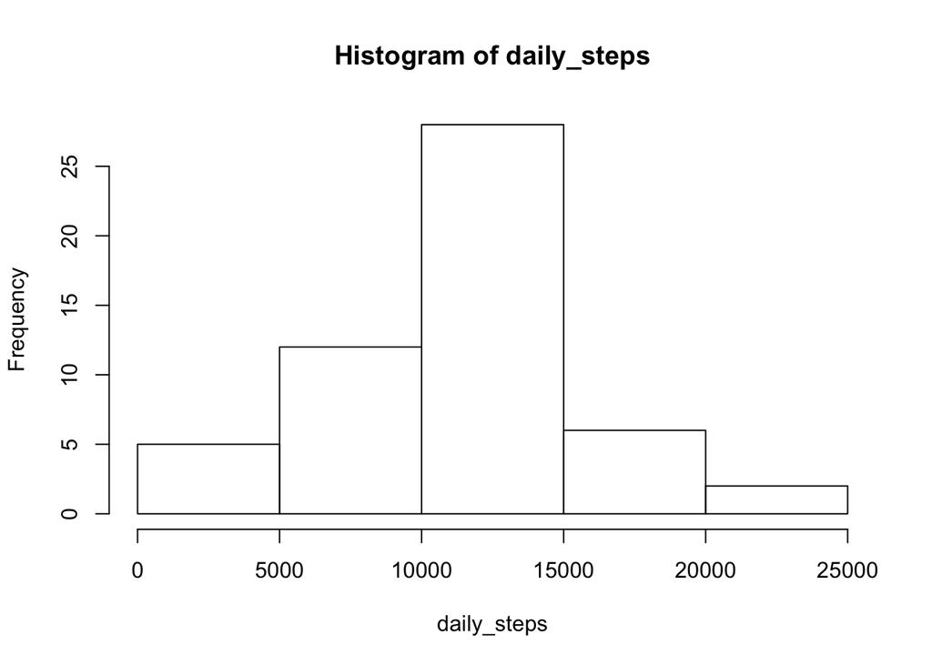

```r
c <- complete_act #lazeh
a <- bydate_act  #lazy
daily_steps <- vector()
for(date in bydate_act){
  daily_steps <- append(daily_steps, as.numeric(sum(date$steps)))
}
myhist <- hist(daily_steps)
```

```r
daily_mean <- mean(daily_steps)
daily_median <- median(daily_steps)
```

The mean of the per-day steps is 10766.1887  
The median of the per-day steps is 10765

### What is the average daily activity pattern?

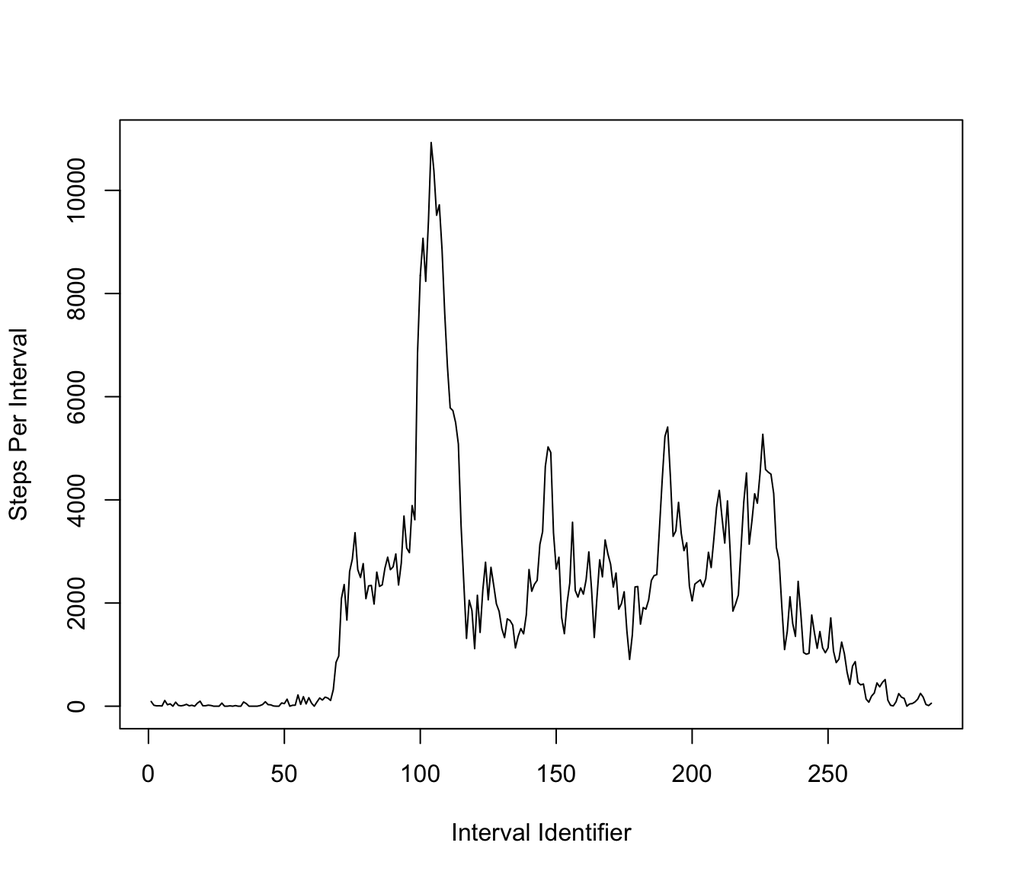

```r
by_interval_act <- split(complete_act, complete_act$interval, drop=TRUE)
interval_steps <- vector()
for(interval in by_interval_act){
  interval_steps <- append(interval_steps, sum(interval$steps))
}
plot(interval_steps, type="l", ylab = "Steps Per Interval", xlab = "Interval Identifier")
```

```r
max_interval <- which.max(interval_steps)
```

The interval with the most steps is interval 104

### Imputing missing values

```r
total_count <- length(act$date)
temp <- act[complete.cases(act),]
complete_count <- length(temp$date)
no_of_na <- total_count - complete_count
```

The number of cases containing an NA is 2304 The strategy for filling in the missing blanks is to take the mean of each interval and then match up the interval that’s NA and replace with the interval mean for that interval.

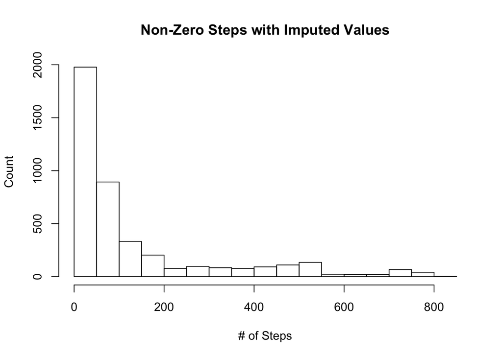

```r
na_act <- act
interval_avg <- aggregate(act$steps ~ act$interval, FUN=mean)
names(interval_avg) <- c("interval", "avsteps")
ia <- interval_avg
for(i in 1:nrow(na_act)){
  if(is.na(na_act[i,1]) == TRUE){
    na_act[i,1] <- ia[ia$interval == na_act[i,3],]$avsteps

    }
}
hist(na_act$steps[act$steps!=0], main="Non-Zero Steps with Imputed Values", xlab="# of Steps", ylab="Count")
```

```r
na_means <- aggregate(na_act$steps ~ na_act$date, FUN=mean)
orig_means <- aggregate(act$steps ~ act$date, FUN=mean)
```

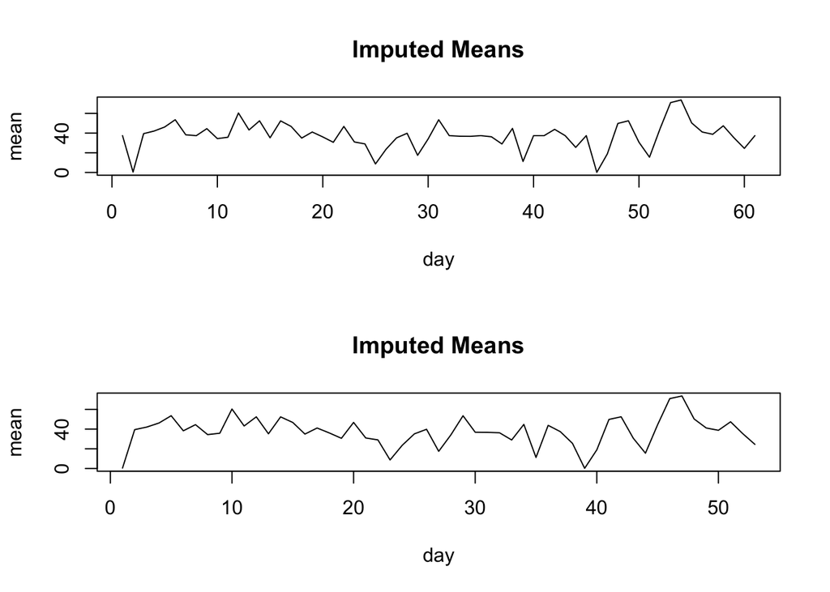

```r
na_medians <- aggregate(na_act$steps ~ na_act$date, FUN=median)
orig_medians <- aggregate(act$steps ~ act$date, FUN=median, na.rm=TRUE)
par(mfrow=c(2,1))
plot(na_means[,2], type="l",main="Imputed Means", xlab="day", ylab="mean")
plot(orig_means[,2], type="l", main="Imputed Means", xlab="day", ylab="mean")
```

Regarding the impact on the total # of steps per day, these two graphs illustrate the differences:

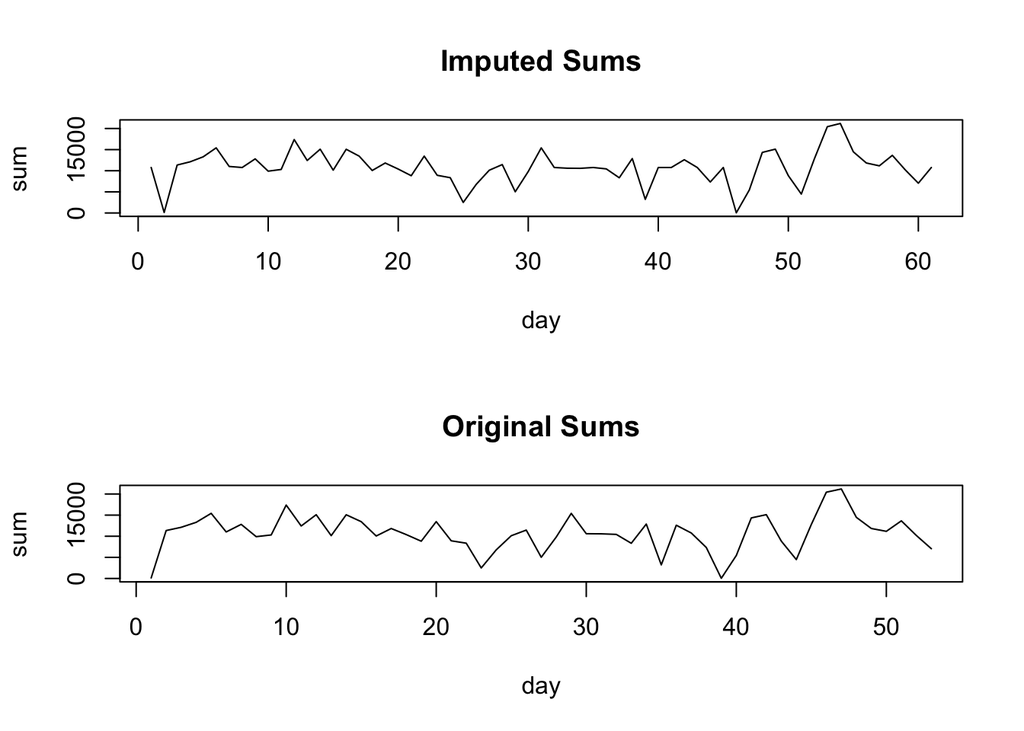

```r
na_sums <- aggregate(na_act$steps ~ na_act$date, FUN=sum)
orig_sums <- aggregate(act$steps ~ act$date, FUN=sum)
par(mfrow=c(2,1))
plot(na_sums[,2], type="l", main="Imputed Sums", xlab="day", ylab="sum")
plot(orig_sums[,2], type="l", main="Original Sums", xlab="day", ylab="sum")
```

So there is not much difference between the data with the NA values and the data with the imputed values.

### Are there differences in activity patterns between weekdays and weekends?

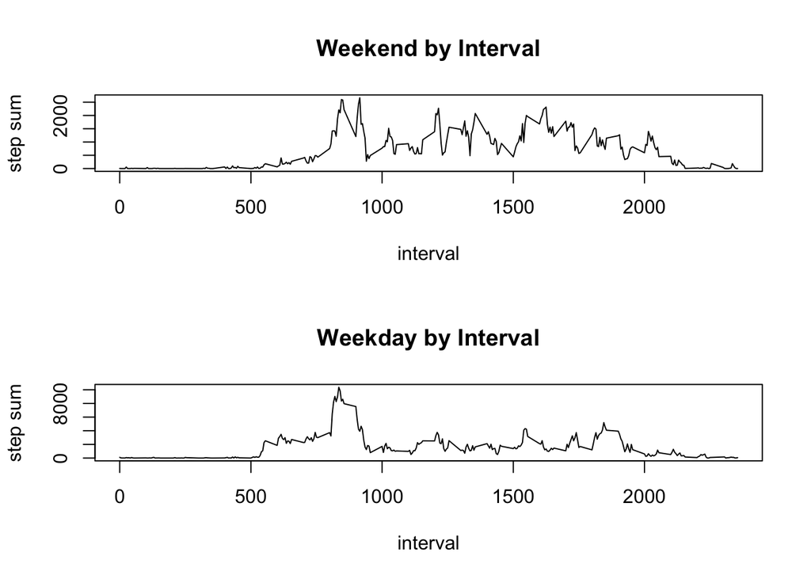

```r
wkact <- na_act
wkact$day <- weekdays(as.POSIXct(act$date))
wkact$daytype[wkact$day %in% c("Saturday", "Sunday")] <- "weekend"
wkact$daytype[wkact$day %in% c("Monday", "Tuesday", "Wednesday", "Thursday", "Friday")] <- "weekday"
par(mfrow=c(2,1))
wknd_by_interval <- aggregate(wkact[wkact$daytype=="weekend",1] ~ wkact[wkact$daytype=="weekend", 3], FUN=sum)
plot(wknd_by_interval, type="l", main = "Weekend by Interval", xlab="interval", ylab = "step sum")
wkdy_by_interval <- aggregate(wkact[wkact$daytype=="weekday",1] ~ wkact[wkact$daytype=="weekday", 3], FUN=sum)
plot(wkdy_by_interval, type="l", main = "Weekday by Interval", xlab="interval", ylab = "step sum")
```